# Prediction of Gallstone Disease

## Overview

This analysis uses the Gallstone dataset from the UCI Machine Learning Repository.[1] Data for this clinical dataset was collected from the Internal Medicine Outpatient Clinic at Ankara VM Medical Park Hospital. The dataset contains records from 319 individuals (June 2022–June 2023), with 161 confirmed cases of gallstone disease. It consists of 38 features, including demographic, bioimpedance, and laboratory data.[2] The objective of this study is to develop predictive models for gallstone disease using these variables. Multiple machine learning classification methods are applied, and model performance is evaluated using AUC-ROC, accuracy, sensitivity, and specificity. Metrics from both cross-validated resampling and the holdout set are compared. The final model is selected based on its overall performance.

```r
library(tidyverse)
library(caret)
library(pROC) # to produce ROC
```

## The Dataset

```r
gallstones <- readxl::read_excel("gallstones.xlsx")
```

## Data Cleaning

```r
str(gallstones)
```

```
## tibble [319 × 39] (S3: tbl_df/tbl/data.frame)
##  $ Gallstone Status                              : num [1:319] 0 0 0 0 0 0 0 0 0 0 ...
##  $ Age                                           : num [1:319] 50 47 61 41 42 96 37 41 38 38 ...
##  $ Gender                                        : num [1:319] 0 0 0 0 0 0 0 0 0 0 ...
##  $ Comorbidity                                   : num [1:319] 0 1 0 0 0 0 0 0 0 0 ...
##  $ Coronary Artery Disease (CAD)                 : num [1:319] 0 0 0 0 0 0 0 0 0 0 ...
##  $ Hypothyroidism                                : num [1:319] 0 0 0 0 0 0 0 0 0 0 ...
##  $ Hyperlipidemia                                : num [1:319] 0 0 0 0 0 0 0 0 0 0 ...
##  $ Diabetes Mellitus (DM)                        : num [1:319] 0 0 0 0 0 0 0 0 0 0 ...
##  $ Height                                        : num [1:319] 185 176 171 168 178 155 185 176 186 171 ...
##  $ Weight                                        : num [1:319] 92.8 94.5 91.1 67.7 89.6 49 67.1 114 93.7 68.6 ...
##  $ Body Mass Index (BMI)                         : num [1:319] 27.1 30.5 31.2 24 28.3 20.4 19.6 36.8 27.1 23.5 ...
##  $ Total Body Water (TBW)                        : num [1:319] 52.9 43.1 47.2 41.4 51.4 34 41.8 57.6 51.9 39.5 ...
##  $ Extracellular Water (ECW)                     : num [1:319] 21.2 19.5 20.1 17 20 15.7 17.1 23.5 20.9 16.6 ...
##  $ Intracellular Water (ICW)                     : num [1:319] 31.7 23.6 27.1 24.4 31.4 18.3 24.7 34.1 31 22.9 ...
```

[output cut: 25 more lines]

```r
sum(is.na(gallstones))
```

```
## [1] 0
```

```r
#Rename and convert to factor variables
gallstones.cleaned <- gallstones |>
        dplyr::select(
                gallstone = `Gallstone Status`,
                age = Age,
                gender = Gender,
                comorbid = Comorbidity,
                cad = `Coronary Artery Disease (CAD)`,
                hypothyroidism = Hypothyroidism,
                hyperlipidemia = Hyperlipidemia,
                diabetes = `Diabetes Mellitus (DM)`,
                height = Height,
                weight = Weight,
                bmi = `Body Mass Index (BMI)`,
                tbw = `Total Body Water (TBW)`,
                ecw = `Extracellular Water (ECW)`,
                icw = `Intracellular Water (ICW)`,
                ecf_tbw_ratio = `Extracellular Fluid/Total Body Water (ECF/TBW)`,
                tbfr = `Total Body Fat Ratio (TBFR) (%)`,
                lean_mass = `Lean Mass (LM) (%)`,
                protein = `Body Protein Content (Protein) (%)`,
                vfr = `Visceral Fat Rating (VFR)`,
                bone_mass = `Bone Mass (BM)`,
                muscle_mass = `Muscle Mass (MM)`,
                obesity = `Obesity (%)`,
                tfc = `Total Fat Content (TFC)`,
                vfa = `Visceral Fat Area (VFA)`,
                vma = `Visceral Muscle Area (VMA) (Kg)`,
                hfa = `Hepatic Fat Accumulation (HFA)`,
                glucose = Glucose,
                tc = `Total Cholesterol (TC)`,
                ldl = `Low Density Lipoprotein (LDL)`,
                hdl = `High Density Lipoprotein (HDL)`,
                triglyceride = Triglyceride,
                ast = `Aspartat Aminotransferaz (AST)`,
                alt = `Alanin Aminotransferaz (ALT)`,
                alp = `Alkaline Phosphatase (ALP)`,
                creatinine = Creatinine,
                gfr = `Glomerular Filtration Rate (GFR)`,
                crp = `C-Reactive Protein (CRP)`,
                hb = `Hemoglobin (HGB)`,
                vit_d = `Vitamin D`
                ) |>
        mutate(
                gallstone = factor(gallstone),
                gender = factor(gender),
                comorbid = factor(comorbid),
                cad = factor(cad),
                hypothyroidism = factor(hypothyroidism),
                hyperlipidemia = factor(hyperlipidemia),
                diabetes = factor(diabetes),
                hfa = factor(hfa)
        )

# recode the target variable compatible to be used in caret
gallstones.cleaned$gallstone <- factor(
  gallstones.cleaned$gallstone,
  levels = c("0", "1"),
  labels = c("yes", "no")  # present 0 (Yes), absent 1 (No) as described in class labels
)
```

For comorbidity, there are only three observations with more than one comorbid condition. Therefore, these will be grouped into a binary variable indicating whether a person has any comorbid condition or not, to avoid sparse categories that could lead to unstable estimates or reduce model reliability.

```r
# if comorbid present, then comorbid = 1, else 0
# because there are only 3 observations for comorbid > 1
gallstones.cleaned <- gallstones.cleaned |>
        mutate(comorbid = fct_recode(comorbid,
                                     "0" = "0",
                                     "1" = "1",
                                     "1" = "2", # 1 or more comorbidities become 1
                                     "1" = "3"))
summary(gallstones.cleaned)
```

```
##  gallstone      age        gender  comorbid cad     hypothyroidism
##  yes:161   Min.   :20.00   0:162   0:217    0:307   0:310
##  no :158   1st Qu.:38.50   1:157   1:102    1: 12   1:  9
##            Median :49.00
##            Mean   :48.07
##            3rd Qu.:56.00
##            Max.   :96.00
##  hyperlipidemia diabetes     height          weight            bmi
##  0:311          0:276    Min.   :145.0   Min.   : 42.90   Min.   :17.40
##  1:  8          1: 43    1st Qu.:159.5   1st Qu.: 69.60   1st Qu.:25.25
##                          Median :168.0   Median : 78.80   Median :28.30
##                          Mean   :167.2   Mean   : 80.56   Mean   :28.88
##                          3rd Qu.:175.0   3rd Qu.: 91.25   3rd Qu.:31.85
##                          Max.   :191.0   Max.   :143.50   Max.   :49.70
##       tbw             ecw             icw        ecf_tbw_ratio
##  Min.   :13.00   Min.   : 9.00   Min.   :13.80   Min.   :29.23
##  1st Qu.:34.20   1st Qu.:14.80   1st Qu.:19.30   1st Qu.:40.08
##  Median :39.80   Median :17.10   Median :23.00   Median :42.00
##  Mean   :40.59   Mean   :17.07   Mean   :23.63   Mean   :42.21
##  3rd Qu.:47.00   3rd Qu.:19.40   3rd Qu.:27.55   3rd Qu.:44.00
##  Max.   :66.20   Max.   :27.80   Max.   :57.10   Max.   :52.00
##       tbfr         lean_mass        protein           vfr
##  Min.   : 6.30   Min.   :48.99   Min.   : 5.56   Min.   : 1.000
##  1st Qu.:22.02   1st Qu.:65.17   1st Qu.:14.46   1st Qu.: 6.000
##  Median :27.82   Median :72.11   Median :15.87   Median : 9.000
##  Mean   :28.27   Mean   :71.64   Mean   :15.94   Mean   : 9.078
##  3rd Qu.:34.81   3rd Qu.:77.85   3rd Qu.:17.43   3rd Qu.:12.000
##  Max.   :50.92   Max.   :93.67   Max.   :24.81   Max.   :31.000
##    bone_mass      muscle_mass       obesity             tfc
##  Min.   :1.400   Min.   : 4.70   Min.   :   0.40   Min.   : 3.10
##  1st Qu.:2.400   1st Qu.:45.80   1st Qu.:  13.90   1st Qu.:17.00
##  Median :2.800   Median :53.90   Median :  25.60   Median :22.60
##  Mean   :2.803   Mean   :54.27   Mean   :  35.85   Mean   :23.49
##  3rd Qu.:3.200   3rd Qu.:62.60   3rd Qu.:  41.75   3rd Qu.:28.55
##  Max.   :4.000   Max.   :78.80   Max.   :1954.00   Max.   :62.50
##       vfa             vma        hfa        glucose            tc
##  Min.   : 0.90   Min.   :18.90   0:129   Min.   : 69.0   Min.   : 60.0
##  1st Qu.: 8.57   1st Qu.:27.25   1: 41   1st Qu.: 92.0   1st Qu.:172.0
##  Median :11.59   Median :30.41   2:122   Median : 98.0   Median :198.0
##  Mean   :12.17   Mean   :30.40   3: 26   Mean   :108.7   Mean   :203.5
```

[output cut: 8 more lines]

```
##  Max.   :293.0   Max.   :273.00   Max.   :838.00   Max.   :195.00
##       alt              alp           creatinine          gfr
##  Min.   :  3.00   Min.   :  7.00   Min.   :0.4600   Min.   : 10.60
##  1st Qu.: 14.25   1st Qu.: 58.00   1st Qu.:0.6500   1st Qu.: 94.17
##  Median : 19.00   Median : 71.00   Median :0.7900   Median :104.00
##  Mean   : 26.86   Mean   : 73.11   Mean   :0.8006   Mean   :100.82
##  3rd Qu.: 30.00   3rd Qu.: 86.00   3rd Qu.:0.9200   3rd Qu.:110.75
##  Max.   :372.00   Max.   :197.00   Max.   :1.4600   Max.   :132.00
##       crp               hb            vit_d
##  Min.   : 0.000   Min.   : 8.50   Min.   : 3.50
##  1st Qu.: 0.000   1st Qu.:13.30   1st Qu.:13.25
##  Median : 0.215   Median :14.40   Median :22.00
##  Mean   : 1.854   Mean   :14.42   Mean   :21.40
##  3rd Qu.: 1.615   3rd Qu.:15.70   3rd Qu.:28.06
##  Max.   :43.400   Max.   :18.80   Max.   :53.10
```

```r
gallstones.cleaned |>
        filter(obesity > 100) |>
        select(obesity)
```

```
## # A tibble: 3 × 1
##   obesity
##     <dbl>
## 1    126.
## 2    106.
## 3   1954
```

```r
# There are three observations with obesity > 100%, which is not possible. Therefore, these three observations will be removed from the dataset.
gallstones.cleaned <- gallstones.cleaned |>
        filter(obesity <= 100)
gallstones.cleaned |> select(obesity) |> summary()
```

```
##     obesity
##  Min.   : 0.40
##  1st Qu.:13.88
##  Median :25.07
##  Mean   :29.27
##  3rd Qu.:41.62
##  Max.   :96.63
```

There are three observations with obesity > 100%, which is not possible. Therefore, these three observations are removed from the dataset.

For variables that capture the same underlying clinical information, only one will be retained, specifically the measure that offers greater clinical relevance/importance or richer information. Detailed justification for the choice of variable is included under dimensionality reduction section.

```r
# The choice among predictors conveying same clinical information
# height, weight, bmi -> bmi
# hyperlipidemia vs triglycerides, tc, ldl, hdl -> triglycerides, tc, ldl, hdl
# diabetes vs glucose -> diabetes
# creatinine vs gfr -> creatinine

gallstones.cleaned <- gallstones.cleaned |>
        dplyr::select(
                -c(height, weight, hyperlipidemia, glucose, gfr)
        )
```

```r
# Identification of near zero variance predictors
numeric_var <- gallstones.cleaned |>
        dplyr::select(where(is.numeric))
nzv <- nearZeroVar(numeric_var, saveMetrics = TRUE)
all(nzv$zeroVar == FALSE)
```

```
## [1] TRUE
```

```r
all(nzv$nzv == FALSE)
```

```
## [1] TRUE
```

```r
nzv
```

```
##               freqRatio percentUnique zeroVar   nzv
## age            1.200000     17.405063   FALSE FALSE
## bmi            1.000000     50.632911   FALSE FALSE
## tbw            1.000000     62.341772   FALSE FALSE
## ecw            1.083333     34.177215   FALSE FALSE
## icw            1.200000     43.354430   FALSE FALSE
## ecf_tbw_ratio  1.054054     25.316456   FALSE FALSE
## tbfr           1.000000     71.202532   FALSE FALSE
## lean_mass      1.000000     92.088608   FALSE FALSE
## protein        1.333333     81.012658   FALSE FALSE
## vfr            1.241379      6.645570   FALSE FALSE
## bone_mass      1.037037      7.594937   FALSE FALSE
## muscle_mass    1.000000     68.354430   FALSE FALSE
## obesity        1.000000     86.392405   FALSE FALSE
## tfc            1.250000     66.139241   FALSE FALSE
## vfa            1.200000     65.506329   FALSE FALSE
## vma            1.200000     56.645570   FALSE FALSE
## tc             1.333333     47.468354   FALSE FALSE
## ldl            1.142857     42.721519   FALSE FALSE
## hdl            1.200000     19.936709   FALSE FALSE
## triglyceride   1.200000     56.012658   FALSE FALSE
## ast            1.240000     13.924051   FALSE FALSE
## alt            1.315789     21.202532   FALSE FALSE
## alp            1.200000     30.696203   FALSE FALSE
## creatinine     1.071429     24.050633   FALSE FALSE
## crp           13.888889     36.708861   FALSE FALSE
## hb             1.083333     26.265823   FALSE FALSE
## vit_d          1.250000     74.367089   FALSE FALSE
```

There is no missing value nor near zero variance predictor.

## Dimensionality reduction

Although the Gallstone dataset includes a relatively large number of predictors compared with the number of observations, we do not want to sacrifice interpretability in exchange for computational benefits. Many predictors, such as demographic, bioimpedance, and laboratory features carry direct clinical meaning, and dimensionality reduction techniques like PCA would obscure these relationships by transforming them into latent components. Instead of reducing dimensionality through unsupervised methods, we rely on model-based feature reduction strategies that preserve interpretability. Techniques such as lasso regression, which performs feature selection through regularization, and tree-based models like random forest, which are naturally robust to multicollinearity, allow us to manage the relatively high predictor-to-sample ratio without losing clinical insight. Therefore, PCA or similar approaches are not applied in this analysis.

However, for variables that capture the same underlying clinical construct, only one will be retained – specifically the measure that offers greater clinical relevance or richer information. For example, height, weight, and BMI all describe body size; in this case, BMI will be selected because it provides a standardized and widely used indicator. Similarly, hyperlipidemia will be excluded in favor of its component laboratory measures (triglycerides, LDL, and total cholesterol), which offer more granular information. For diabetes versus glucose, diabetes status will be retained because it reflects a clinically established diagnosis rather than a single point glucose measurement. Finally, creatinine and estimated GFR are highly correlated, and because GFR is typically calculated from creatinine along with age and sex (which are already included as predictors), creatinine will be kept as the more direct measurement.

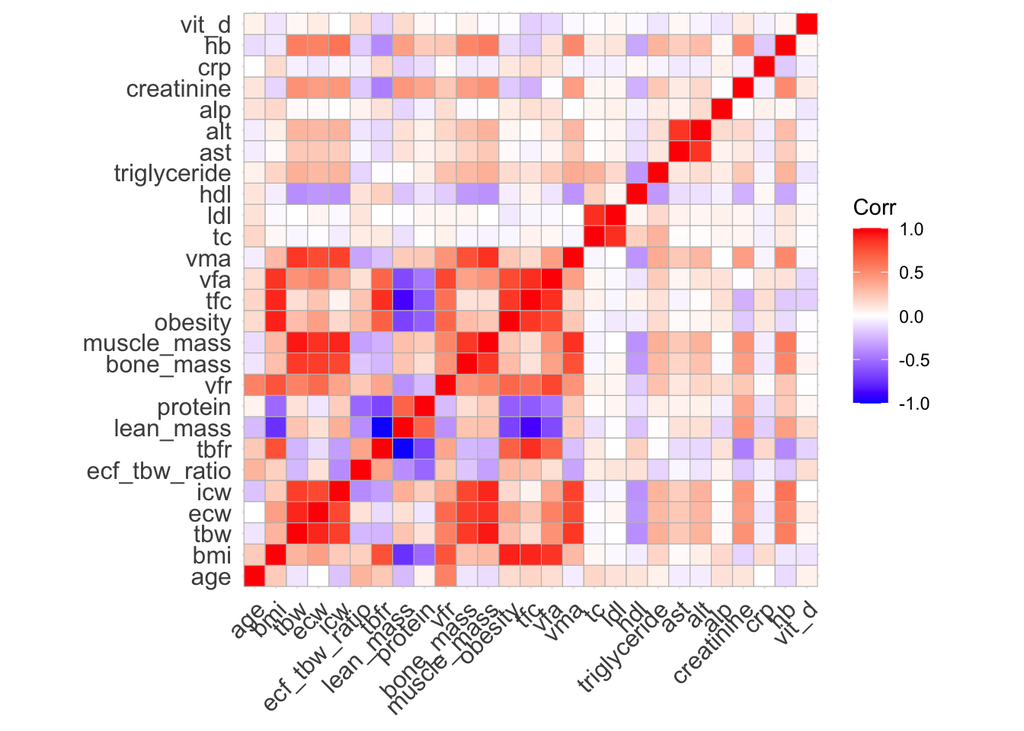

```r
# Correlation matrix plot
corr_matrix <- gallstones.cleaned |>
        dplyr::select(where(is.numeric)) |>
        cor(use = "pairwise.complete.obs")
ggcorrplot::ggcorrplot(corr_matrix)
```

There are many highly correlated pairs in the dataset, which will be addressed in the preprocessing step prior to model training.

## Data Partitioning

```r
# Partitioning the dataset
set.seed(5330)
# 80% for training-validation, 20% for holdout
inTraining <- createDataPartition(gallstones.cleaned$gallstone, p = 0.8, list = FALSE)
training <- gallstones.cleaned[inTraining, ]
holdout <- gallstones.cleaned[-inTraining, ]
dim(training)
```

```
## [1] 253  34
```

```r
dim(holdout)
```

```
## [1] 63 34
```

## Preprocessing the data frame

```r
# Preprocessing
# centering, scaling, and addressing correlation as part of the pre-processing step
preProcValues <- preProcess(training,
                            method = c("center", "scale", "corr"),
                            cutoff = 0.7) # cutoff for correlation

# create the scaled+centered of the training+testing subset of the dataset
trainTransformed <- predict(preProcValues, training)
# apply the same scaling and centering on the holdout set
holdoutTransformed <- predict(preProcValues, holdout)
```

There are many highly correlated pairs in the dataset. If correlation is not addressed in the preprocessing, model training on several models returns errors.

## Cross-validation setup

```r
fitControl <- trainControl(
  method = "repeatedcv", ## perform repeated k-fold CV
  number = 10,
  repeats = 3,
  classProbs = TRUE,
  summaryFunction = twoClassSummary,
  savePredictions = "final"
  )
```

## Logistic Regression

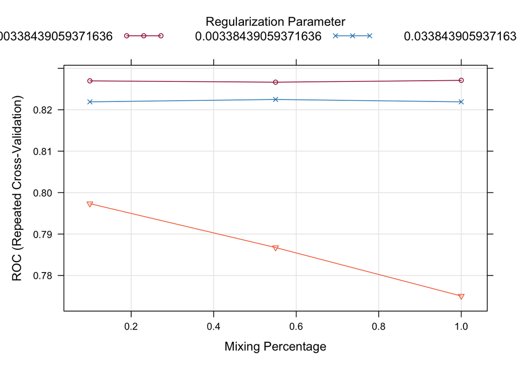

```r
# Logistic regression model
# train the model
set.seed(5330)
logit_model <- train(
        gallstone ~ .,
        data = trainTransformed,
        method = "glmnet",
        metric = "ROC",
        trControl = fitControl,
        preProcess = "nzv" #to handle nzv in trainTransformed set if present
)
# tuning plot
trellis.par.set(caretTheme())
plot(logit_model)
```

```r
logit_model$bestTune
```

```
##   alpha       lambda
## 7     1 0.0003384391
```

```r
# prediction on the holdout set
preds <- predict(logit_model, newdata = holdoutTransformed)
(cm_logit <- confusionMatrix(preds, holdoutTransformed$gallstone))
```

```
## Confusion Matrix and Statistics
##
##           Reference
## Prediction yes no
##        yes  28  6
##        no    4 25
##
##                Accuracy : 0.8413
##                  95% CI : (0.7274, 0.9212)
##     No Information Rate : 0.5079
##     P-Value [Acc > NIR] : 3.343e-08
##
##                   Kappa : 0.6821
##
##  Mcnemar's Test P-Value : 0.7518
##
##             Sensitivity : 0.8750
##             Specificity : 0.8065
##          Pos Pred Value : 0.8235
##          Neg Pred Value : 0.8621
##              Prevalence : 0.5079
##          Detection Rate : 0.4444
##    Detection Prevalence : 0.5397
##       Balanced Accuracy : 0.8407
##
##        'Positive' Class : yes
##
```

```r
# rank the variables in terms of their importance
varImp(logit_model)
```

```
## glmnet variable importance
##
##               Overall
## crp           100.000
## hfa3           82.099
## gender1        56.690
## diabetes1      55.585
## protein        53.083
## hfa2           49.541
## ecf_tbw_ratio  49.170
## vit_d          39.331
## hb             28.320
## obesity        27.743
## hfa1           27.603
## bone_mass      24.092
## comorbid1      15.470
## age            14.847
## triglyceride   12.965
## alp             5.473
## ast             5.108
## tc              4.172
## hdl             1.865
## creatinine      0.000
```

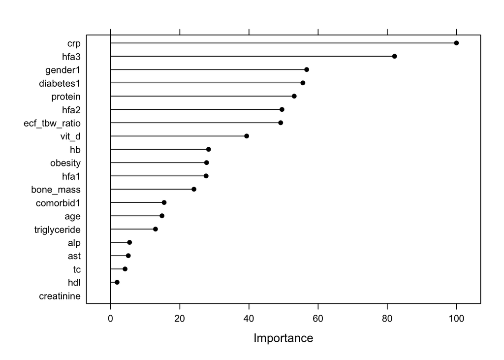

```r
trellis.par.set(caretTheme())
plot(varImp(logit_model))
```

```r
#ROC on the holdout set
probs <- predict(logit_model, holdoutTransformed, type = "prob")[, "yes"]
true <- holdoutTransformed$gallstone
roc_obj <- roc(true, probs)
# AUC
auc_logit <- auc(roc_obj)
```

## Linear Discriminant Analysis

```r
# LDA
set.seed(5330)
lda_model <- train(
        gallstone ~ .,
        data = trainTransformed,
        method = "lda",
        metric = "ROC",
        trControl = fitControl,
        preProcess = "nzv" #to handle nzv in trainTransformed set if present
        )
# Prediction
preds <- predict(lda_model, newdata = holdoutTransformed)
# ConfusionMatrix
(cm_lda <- confusionMatrix(preds, holdoutTransformed$gallstone))
```

```
## Confusion Matrix and Statistics
##
##           Reference
## Prediction yes no
##        yes  27  6
##        no    5 25
##
##                Accuracy : 0.8254
##                  95% CI : (0.709, 0.9095)
##     No Information Rate : 0.5079
##     P-Value [Acc > NIR] : 1.604e-07
##
##                   Kappa : 0.6505
##
##  Mcnemar's Test P-Value : 1
##
##             Sensitivity : 0.8438
##             Specificity : 0.8065
##          Pos Pred Value : 0.8182
##          Neg Pred Value : 0.8333
##              Prevalence : 0.5079
##          Detection Rate : 0.4286
##    Detection Prevalence : 0.5238
##       Balanced Accuracy : 0.8251
##
##        'Positive' Class : yes
##
```

```r
# variable importance LDA
# extract scalings to calculate importance
imp_lda <- lda_model$finalModel$scaling
imp_lda <- data.frame(
        variable = rownames(imp_lda),
        importance = abs(imp_lda[,1])
)
rownames(imp_lda) <- NULL
# rank the variables in terms of their importance
imp_lda_top10 <-
        imp_lda |>
        arrange(desc(importance)) |>
        head(10)
imp_lda_top10
```

```
##         variable importance
## 1           hfa3  1.1976192
## 2      diabetes1  0.9053986
## 3        gender1  0.8377410
## 4           hfa2  0.7643402
## 5  ecf_tbw_ratio  0.6214849
## 6          vit_d  0.6211102
## 7        protein  0.5163295
## 8           hfa1  0.4451209
## 9      bone_mass  0.4396766
## 10            hb  0.4147273
```

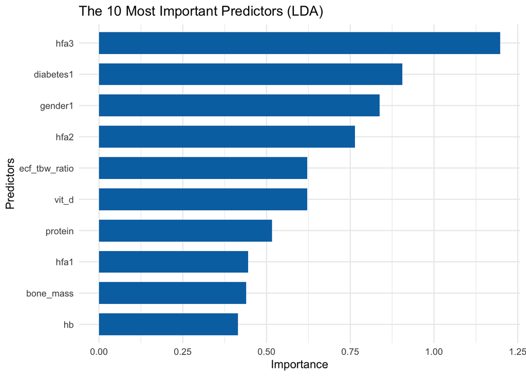

```r
# Plot
ggplot(imp_lda_top10, aes( x = reorder(variable, importance), y = importance)) +
        geom_bar(stat = "identity", fill = "#0072B2", width = 0.7) +
        coord_flip() +
        labs(title = "The 10 Most Important Predictors (LDA)",
             x = "Predictors",
             y = "Importance") +
        theme_minimal()
```

```r
#ROC on the holdout set
probs <- predict(lda_model, holdoutTransformed, type = "prob")[, "yes"]
true <- holdoutTransformed$gallstone
roc_obj <- roc(true, probs)
# AUC
auc_lda <- auc(roc_obj)
```

## Quadratic Discriminant Analysis

```r
# QDA
set.seed(5330)
qda_model <- train(
        gallstone ~ .,
        data = training, #qda fit returns errors when used trainTransformed
        method = "qda",
        metric = "ROC",
        trControl = fitControl,
        preProcess = c("corr", "nzv")
        )
# Prediction
preds <- predict(qda_model, newdata = holdout)
# ConfusionMatrix
(cm_qda <- confusionMatrix(preds, holdout$gallstone))
```

```
## Confusion Matrix and Statistics
##
##           Reference
## Prediction yes no
##        yes  30  6
##        no    2 25
##
##                Accuracy : 0.873
##                  95% CI : (0.765, 0.9435)
##     No Information Rate : 0.5079
##     P-Value [Acc > NIR] : 1.026e-09
##
##                   Kappa : 0.7455
##
##  Mcnemar's Test P-Value : 0.2888
##
##             Sensitivity : 0.9375
##             Specificity : 0.8065
##          Pos Pred Value : 0.8333
##          Neg Pred Value : 0.9259
##              Prevalence : 0.5079
##          Detection Rate : 0.4762
##    Detection Prevalence : 0.5714
##       Balanced Accuracy : 0.8720
##
##        'Positive' Class : yes
##
```

```r
#ROC on the holdout set
probs <- predict(qda_model, holdout, type = "prob")[, "yes"]
true <- holdout$gallstone
roc_obj <- roc(true, probs)
# AUC
auc_qda <- auc(roc_obj)
```

## K-Nearest Neighbors

```r
#KNN
# tune grid for knn
knn_grid <- expand.grid(k = seq(3, 31, by = 2)) # select odd values of k
# train knn
set.seed(5330)
knn_model <- train(
        gallstone ~ .,
        data = trainTransformed,
        method = "knn",
        metric = "ROC", #The metric "Accuracy" was not in the result set
        trControl = fitControl,
        tuneGrid = knn_grid
)
knn_model
```

```
## k-Nearest Neighbors
##
## 253 samples
##  20 predictor
##   2 classes: 'yes', 'no'
##
## No pre-processing
## Resampling: Cross-Validated (10 fold, repeated 3 times)
## Summary of sample sizes: 228, 227, 228, 228, 228, 228, ...
## Resampling results across tuning parameters:
##
##   k   ROC        Sens       Spec
##    3  0.6928104  0.7155983  0.6145299
##    5  0.7394669  0.7645299  0.5852564
##    7  0.7412510  0.7754274  0.5474359
##    9  0.7443123  0.8173077  0.5326923
##   11  0.7492891  0.8175214  0.5217949
##   13  0.7382116  0.8358974  0.4920940
##   15  0.7284941  0.8384615  0.4822650
##   17  0.7301193  0.8489316  0.4957265
##   19  0.7358057  0.8568376  0.5010684
##   21  0.7363871  0.8489316  0.4773504
##   23  0.7339463  0.8463675  0.4769231
##   25  0.7415708  0.8386752  0.4664530
##   27  0.7486371  0.8489316  0.4611111
##   29  0.7487426  0.8491453  0.4591880
##   31  0.7574081  0.8489316  0.4670940
##
## ROC was used to select the optimal model using the largest value.
## The final value used for the model was k = 31.
```

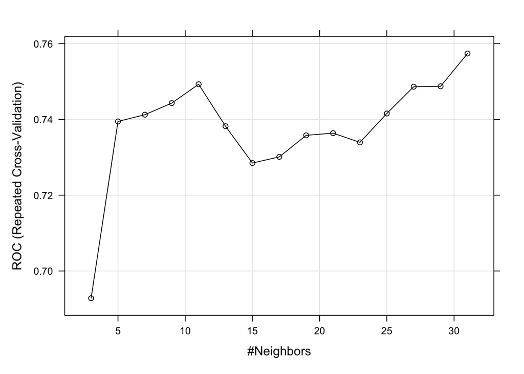

```r
plot(knn_model)
```

```r
# Prediction on the holdoutTransformed set
preds <- predict(knn_model, holdoutTransformed)
# Performance on the holdout set
(cm_knn <- confusionMatrix(preds, holdoutTransformed$gallstone))
```

```
## Confusion Matrix and Statistics
##
##           Reference
## Prediction yes no
##        yes  27 12
##        no    5 19
##
##                Accuracy : 0.7302
##                  95% CI : (0.6035, 0.8343)
##     No Information Rate : 0.5079
##     P-Value [Acc > NIR] : 0.000269
##
##                   Kappa : 0.4583
##
##  Mcnemar's Test P-Value : 0.145610
##
##             Sensitivity : 0.8438
##             Specificity : 0.6129
##          Pos Pred Value : 0.6923
##          Neg Pred Value : 0.7917
##              Prevalence : 0.5079
##          Detection Rate : 0.4286
##    Detection Prevalence : 0.6190
##       Balanced Accuracy : 0.7283
##
##        'Positive' Class : yes
##
```

```r
#ROC on the holdout set
probs <- predict(knn_model, holdoutTransformed, type = "prob")[, "yes"]
true <- holdoutTransformed$gallstone
roc_obj <- roc(true, probs)
# AUC
auc_knn <- auc(roc_obj)
```

FOR QDA and KNN variable importance plot cannot be produced using caret `varImp`.

## Random Forest (Classification)

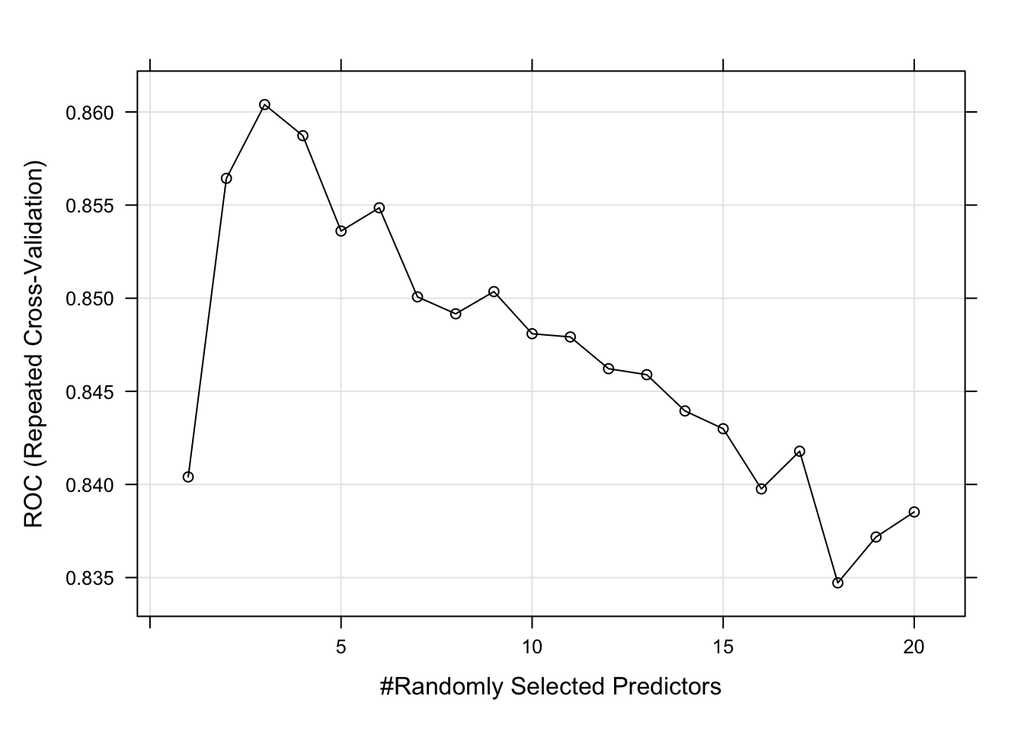

```r
library(doParallel)
## code for running model fitting in parallel
cl <- makePSOCKcluster(detectCores())
## registering a cluster of CPU cores to use parallelization when possible
registerDoParallel(cl)
# RF
#tuning grid for RF
grid <- expand.grid(mtry = 1:(ncol(trainTransformed)-1))
# train model
set.seed(5330)
rf_model <- train(gallstone ~ .,
                   data = trainTransformed,
                   method = "rf",
                   trControl = fitControl,
                   metric = "ROC", # "Accuracy is not in the result set
                   verbose = FALSE,
                   tuneGrid = grid)
## tuning plots
trellis.par.set(caretTheme())
plot(rf_model)
```

```r
## make predictions on the hold-out set
predvals <- predict(rf_model, holdoutTransformed)
## create the confusion matrix
(cm_rf <- confusionMatrix(predvals, holdoutTransformed$gallstone))
```

```
## Confusion Matrix and Statistics
##
##           Reference
## Prediction yes no
##        yes  26  6
##        no    6 25
##
##                Accuracy : 0.8095
##                  95% CI : (0.6909, 0.8975)
##     No Information Rate : 0.5079
##     P-Value [Acc > NIR] : 6.935e-07
##
##                   Kappa : 0.619
##
##  Mcnemar's Test P-Value : 1
##
##             Sensitivity : 0.8125
##             Specificity : 0.8065
##          Pos Pred Value : 0.8125
##          Neg Pred Value : 0.8065
##              Prevalence : 0.5079
##          Detection Rate : 0.4127
##    Detection Prevalence : 0.5079
##       Balanced Accuracy : 0.8095
##
##        'Positive' Class : yes
##
```

```r
## Rank the variables in terms of their importance
varImp(rf_model)
```

```
## rf variable importance
##
##   only 20 most important variables shown (out of 23)
##
##               Overall
## crp           100.000
## vit_d          59.343
## ast            38.752
## ecf_tbw_ratio  37.259
## protein        33.376
## hb             31.822
## creatinine     30.167
## obesity        28.830
## alp            27.914
## hdl            26.129
## tc             26.107
## triglyceride   25.314
## bone_mass      25.186
## age            25.096
## hfa1           10.166
## hfa2            7.390
## diabetes1       5.645
## comorbid1       4.720
## gender1         4.246
## hfa3            3.220
```

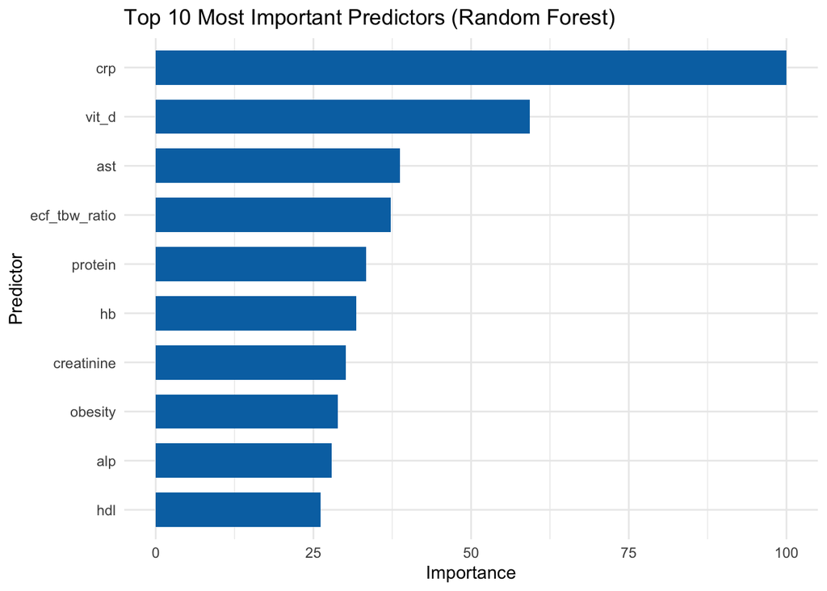

```r
## Variable Importance Plot
var_imp_df <- as.data.frame(varImp(rf_model)$importance)
top10 <- var_imp_df |>
        rownames_to_column("Variable") |>
        arrange(desc(Overall)) |>
        dplyr::slice(1:10)

ggplot(top10, aes(x = reorder(Variable, Overall), y = Overall)) +
  geom_bar(stat = "identity", fill = "#0072B2", width = 0.7)+
  coord_flip() +
  labs(
    title = "Top 10 Most Important Predictors (Random Forest)",
    x = "Predictor",
    y = "Importance"
  ) +
  theme_minimal()
```

```r
#ROC on the holdout set
probs <- predict(rf_model, holdoutTransformed, type = "prob")[, "yes"]
true <- holdoutTransformed$gallstone
roc_obj <- roc(true, probs)
# AUC
auc_rf <- auc(roc_obj)
```

## Stochastic Gradient Boosting Machine (GBM) Model

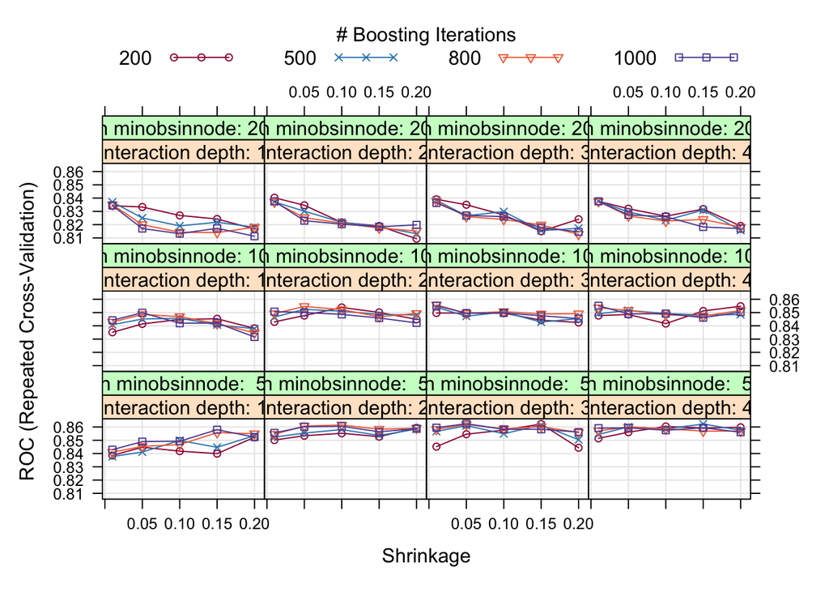

```r
library(gbm)
#GBM
# Hyperparmeters tuning
grid <- expand.grid(interaction.depth = seq(1:4), #depth of each tree
                    shrinkage = c(0.01, 0.05, 0.1, 0.15, 0.2), #learning rate
                    n.trees = c(200, 500, 800, 1000), # Boosting iteration
                    n.minobsinnode = c(5, 10, 20) # terminal node size
                    )

# Train GBM model
set.seed(5330)
gbm_model <- train(gallstone ~ .,
                 data = trainTransformed,
                 method = "gbm",
                 trControl = fitControl,
                 verbose = FALSE,
                 tuneGrid = grid,
                 metric = "ROC"
                 )

trellis.par.set(caretTheme())
plot(gbm_model)
```

```r
# Predictions on the holdout set
preds <- predict(gbm_model, holdoutTransformed)
# Performance metrics (Confusion Matrix)
(cm_gbm <- confusionMatrix(preds, holdoutTransformed$gallstone))
```

```
## Confusion Matrix and Statistics
##
##           Reference
## Prediction yes no
##        yes  24  7
##        no    8 24
##
##                Accuracy : 0.7619
##                  95% CI : (0.6379, 0.8602)
##     No Information Rate : 0.5079
##     P-Value [Acc > NIR] : 3.191e-05
##
##                   Kappa : 0.5239
##
##  Mcnemar's Test P-Value : 1
##
##             Sensitivity : 0.7500
##             Specificity : 0.7742
##          Pos Pred Value : 0.7742
##          Neg Pred Value : 0.7500
##              Prevalence : 0.5079
##          Detection Rate : 0.3810
##    Detection Prevalence : 0.4921
##       Balanced Accuracy : 0.7621
##
##        'Positive' Class : yes
##
```

```r
# variable importance
varImp(gbm_model)
```

```
## gbm variable importance
##
##   only 20 most important variables shown (out of 23)
##
##                Overall
## crp           100.0000
## vit_d          47.9718
## protein        34.2085
## tc             26.9793
## creatinine     25.7892
## hb             25.6336
## ecf_tbw_ratio  24.6552
## ast            24.5660
## obesity        24.3563
## alp            19.7479
## age            14.8381
## triglyceride   14.5387
## hdl            12.5397
## bone_mass      11.0544
## hfa1            6.8071
## hfa3            6.0701
## diabetes1       3.4991
## hfa2            1.4232
## gender1         0.3413
## comorbid1       0.2321
```

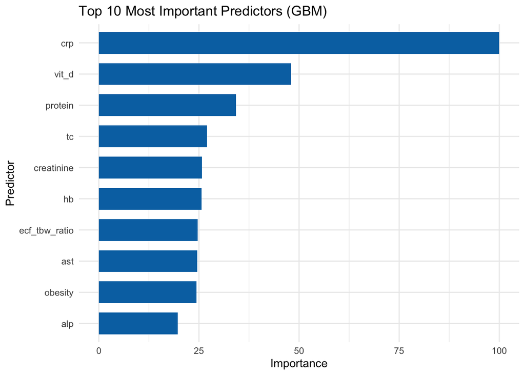

```r
# Variable Importance Plot
var_imp_df <- as.data.frame(varImp(gbm_model)$importance)
top10 <- var_imp_df |>
        rownames_to_column("Variable") |>
        arrange(desc(Overall)) |>
        dplyr::slice(1:10)

ggplot(top10, aes(x = reorder(Variable, Overall), y = Overall)) +
  geom_bar(stat = "identity", fill = "#0072B2", width = 0.7)+
  coord_flip() +
  labs(
    title = "Top 10 Most Important Predictors (GBM)",
    x = "Predictor",
    y = "Importance"
  ) +
  theme_minimal()
```

```r
#ROC on the holdout set
probs <- predict(gbm_model, holdoutTransformed, type = "prob")[, "yes"]
true <- holdoutTransformed$gallstone
roc_obj <- roc(true, probs)
# AUC
auc_gbm <- auc(roc_obj)
```

## Support Vector Machines (SVM)

### Support Vector Machines - Linear (SVM-Linear)

```r
library(e1071)
#SVM
# Hyperparmeters tuning
svm_linear_grid <- expand.grid(
        cost = c(0.01, 0.1, 10, 100, 1000)
        )
# Train SVM Linear model
set.seed(5330)
svm_linear <- train(gallstone ~ .,
                    data = trainTransformed,
                    method = "svmLinear2",
                    trControl = fitControl,
                    verbose = FALSE,
                    metric = "ROC",
                    tuneGrid = svm_linear_grid,
                    preProcess = "nzv"
                    )
# Prediction on the holdout set
preds <- predict(svm_linear, holdoutTransformed)
# Performance metrics (Confusion Matrix)
(cm_svm_linear <- confusionMatrix(preds, holdoutTransformed$gallstone))
```

```
## Confusion Matrix and Statistics
##
##           Reference
## Prediction yes no
##        yes  29  8
##        no    3 23
##
##                Accuracy : 0.8254
##                  95% CI : (0.709, 0.9095)
##     No Information Rate : 0.5079
##     P-Value [Acc > NIR] : 1.604e-07
##
##                   Kappa : 0.6498
##
##  Mcnemar's Test P-Value : 0.2278
##
##             Sensitivity : 0.9062
##             Specificity : 0.7419
##          Pos Pred Value : 0.7838
##          Neg Pred Value : 0.8846
##              Prevalence : 0.5079
##          Detection Rate : 0.4603
##    Detection Prevalence : 0.5873
##       Balanced Accuracy : 0.8241
##
##        'Positive' Class : yes
##
```

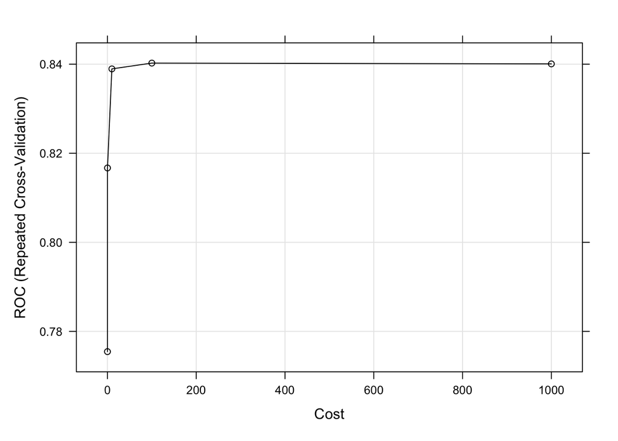

```r
# tuning plot
plot(svm_linear)
```

```r
#varImp(svm_linear) #doesn't work
# Extract coeficients to calculate variable importance
coef_svm <- coef(svm_linear$finalModel)
imp_svm <- data.frame(
        variable = names(coef_svm),
        importance = abs(coef_svm)
        ) |>
                filter(variable != "(Intercept)")# remove intercept
rownames(imp_svm) <- NULL

# rank the variables in terms of their importance
imp_svm_top10 <-
        imp_svm |>
        arrange(desc(importance)) |>
        head(10)
imp_svm_top10
```

```
##         variable importance
## 1            crp  2.5539904
## 2        protein  1.0109184
## 3  ecf_tbw_ratio  0.9393592
## 4        gender1  0.7964607
## 5          vit_d  0.7058666
## 6      bone_mass  0.6947416
## 7             hb  0.5662525
## 8        obesity  0.4161756
## 9           hfa2  0.3919568
## 10          hfa3  0.3695204
```

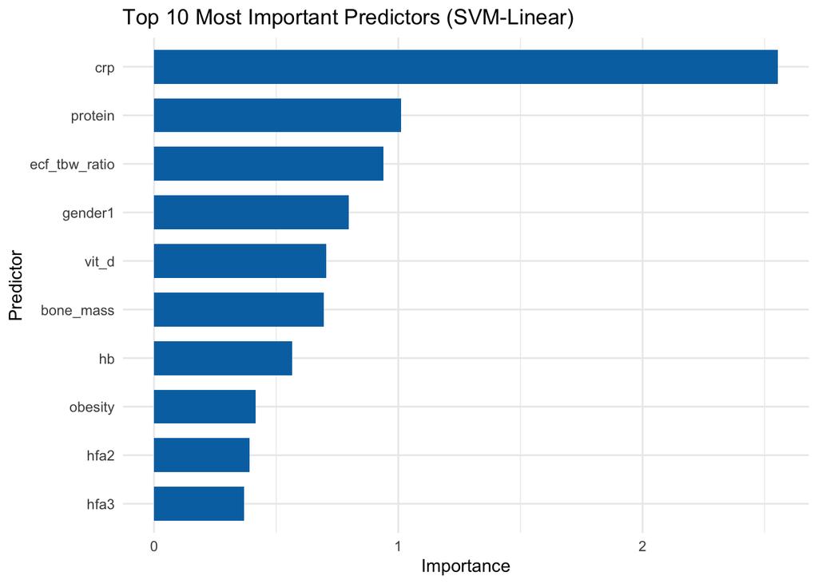

```r
# Variable Importance Plot
ggplot(imp_svm_top10, aes(x = reorder(variable, importance), y = importance)) +
  geom_bar(stat = "identity", fill = "#0072B2", width = 0.7)+
  coord_flip() +
  labs(
    title = "Top 10 Most Important Predictors (SVM-Linear)",
    x = "Predictor",
    y = "Importance"
  ) +
  theme_minimal()
```

```r
#ROC on the holdout set
probs <- predict(svm_linear, holdoutTransformed, type = "prob")[, "yes"]
true <- holdoutTransformed$gallstone
roc_obj <- roc(true, probs)
# AUC
auc_svm <- auc(roc_obj)
```

### Support Vector Machines (SVM-Radial)

```r
# SVM-Radial
# Hyperparmeters tuning
svm_radial_grid <- expand.grid(
        C = c(0.01, 0.1, 10, 50),
        sigma = c(0.01, 0.05, 0.1)
        )
# Train SVM Radial model
set.seed(5330)
svm_radial <- train(gallstone ~ .,
                    data = trainTransformed,
                    method = "svmRadial",
                    trControl = fitControl,
                    verbose = FALSE,
                    metric = "ROC",
                    tuneGrid = svm_radial_grid,
                    preProcess = "nzv"
                    )

# Prediction on the holdout set
preds <- predict(svm_radial, holdoutTransformed)
# Performance metrics (Confusion Matrix)
(cm_svm_radial <- confusionMatrix(preds, holdoutTransformed$gallstone))
```

```
## Confusion Matrix and Statistics
##
##           Reference
## Prediction yes no
##        yes  22  7
##        no   10 24
##
##                Accuracy : 0.7302
##                  95% CI : (0.6035, 0.8343)
##     No Information Rate : 0.5079
##     P-Value [Acc > NIR] : 0.000269
##
##                   Kappa : 0.461
##
##  Mcnemar's Test P-Value : 0.627626
##
##             Sensitivity : 0.6875
##             Specificity : 0.7742
##          Pos Pred Value : 0.7586
##          Neg Pred Value : 0.7059
##              Prevalence : 0.5079
##          Detection Rate : 0.3492
##    Detection Prevalence : 0.4603
##       Balanced Accuracy : 0.7308
##
##        'Positive' Class : yes
##
```

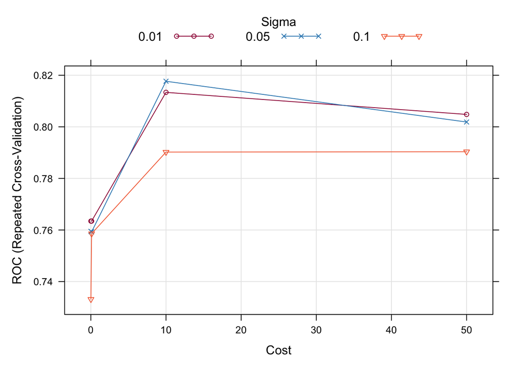

```r
plot(svm_radial)
```

```r
svm_radial$finalModel
```

```
## Support Vector Machine object of class "ksvm"
##
## SV type: C-svc  (classification)
##  parameter : cost C = 10
##
## Gaussian Radial Basis kernel function.
##  Hyperparameter : sigma =  0.05
##
## Number of Support Vectors : 171
##
## Objective Function Value : -374.2056
## Training error : 0.01581
## Probability model included.
```

```r
#ROC on the holdout set
probs <- predict(svm_radial, holdoutTransformed, type = "prob")[, "yes"]
true <- holdoutTransformed$gallstone
roc_obj <- roc(true, probs)
# AUC
auc_svm_radial <- auc(roc_obj)
```

## Comparison of Model Performance

### Resamples (CV)

```r
# Calculate CV Accuracy and merge with resample metrics (ROC, Sens, Spec)
# function to calculate accuracy in resamples (CV)
get_cv_accuracy <- function(model){
        model$pred |>
                mutate(correct = pred == obs) |>
                group_by(Resample) |>
                summarize(Accuracy = mean(correct))
}

# function to extract ROC, Sens, Spec from resamples (CV) and merge with Accuracy
get_cv_metric <- function(model, name){
        inner_join(get_cv_accuracy(model), model$resample, by = "Resample") |>
                mutate(Model = rep(name, 30)) # 30 = 10 folds * 3 repeats
}
cv_results <- bind_rows(
        get_cv_metric(logit_model, "LogReg"),
        get_cv_metric(lda_model, "LDA"),
        get_cv_metric(qda_model, "QDA"),
        get_cv_metric(gbm_model, "GBM"),
        get_cv_metric(knn_model, "KNN"),
        get_cv_metric(rf_model, "RF"),
        get_cv_metric(svm_linear, "svmLinear"),
        get_cv_metric(svm_radial, "svmRadial")
        )

cv_results_long <- cv_results |>
        pivot_longer(cols = c(ROC, Sens, Spec, Accuracy), names_to = "Metric", values_to = "Value")
```

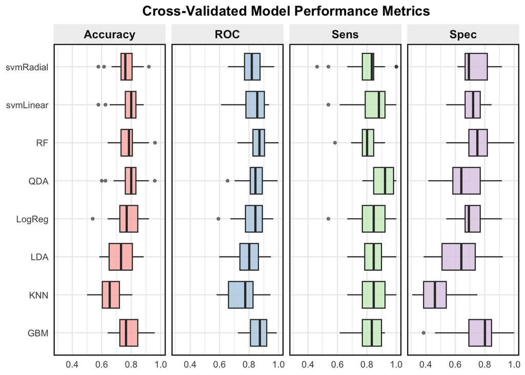

```r
# Plot to compare model performance across CV metrics
ggplot(cv_results_long, aes(x = Value, y = Model, fill = Metric)) +
  geom_boxplot(
    width = 0.7,
    outlier.size = 1,
    outlier.alpha = 0.6,
    lwd = 0.5,
    alpha = 0.8
  ) +
  facet_grid(~ Metric) +
  scale_fill_brewer(palette = "Pastel1") +
  labs(
    title = "Cross-Validated Model Performance Metrics",
    x = NULL,
    y = NULL
  ) +
  theme_minimal() +
  theme(
    legend.position = "none",
    strip.text = element_text(face = "bold", size = 11), # facet label style
    panel.border = element_rect(color = "black", linewidth = 1, fill = NA), # add border around each facet panel
    strip.background = element_rect(fill = "#F0F0F0", color = NA), # facet label background
    plot.title = element_text(face = "bold", hjust = 0.5))
```

```r
# Calculate mean CV metrics for each model
cv_results <-
        cv_results |>
        group_by(Model) |>
        summarize(
                ROC = mean(ROC),
                Accuracy = mean(Accuracy),
                Sensitivity = mean(Sens),
                Specificity = mean(Spec)
  )
cv_results|>
        arrange(desc(ROC), desc(Accuracy),
        desc(Sensitivity), desc(Specificity)) |>
                knitr::kable(
                        format = "markdown",
                        digits = 3,
                        caption = "Cross-Validated Model Performance Summary")
```

Cross-Validated Model Performance Summary

| Model | ROC | Accuracy | Sensitivity | Specificity |
| --- | --- | --- | --- | --- |
| GBM | 0.862 | 0.787 | 0.802 | 0.772 |
| RF | 0.860 | 0.783 | 0.807 | 0.759 |
| QDA | 0.845 | 0.787 | 0.909 | 0.663 |
| svmLinear | 0.840 | 0.778 | 0.849 | 0.706 |
| LogReg | 0.827 | 0.778 | 0.844 | 0.712 |
| svmRadial | 0.818 | 0.766 | 0.803 | 0.728 |
| LDA | 0.792 | 0.740 | 0.839 | 0.638 |
| KNN | 0.757 | 0.660 | 0.849 | 0.467 |

Taken together, GBM demonstrated the best combination of discrimination, specificity, and consistency in resampling. The baseline model, logistic regression, performed solidly and stably with balanced metrics.

### Holdout sets

```r
# Extract holdout set performance metrics and compile into a summary table
logit_results <- tibble(
        Model = "Logistic Regression",
        ROC = as.numeric(round(auc_logit, 3)),
        Accuracy = cm_logit$overall["Accuracy"],
        Sensitivity = cm_logit$byClass["Sensitivity"],
        Specificity = cm_logit$byClass["Specificity"]
        )

lda_results <- tibble(
        Model = "LDA",
        ROC = as.numeric(round(auc_lda, 3)),
        Accuracy = cm_lda$overall["Accuracy"],
        Sensitivity = cm_lda$byClass["Sensitivity"],
        Specificity = cm_lda$byClass["Specificity"]
        )

qda_results <- tibble(
        Model = "QDA",
        ROC = as.numeric(round(auc_qda, 3)),
        Accuracy = cm_qda$overall["Accuracy"],
        Sensitivity = cm_qda$byClass["Sensitivity"],
        Specificity = cm_qda$byClass["Specificity"]
        )

knn_results <- tibble(
        Model = "KNN",
        ROC = as.numeric(round(auc_knn, 3)),
        Accuracy = cm_knn$overall["Accuracy"],
        Sensitivity = cm_knn$byClass["Sensitivity"],
        Specificity = cm_knn$byClass["Specificity"]
        )

rf_results <- tibble(
        Model = "RF",
        ROC = as.numeric(round(auc_rf, 3)),
        Accuracy = cm_rf$overall["Accuracy"],
        Sensitivity = cm_rf$byClass["Sensitivity"],
        Specificity = cm_rf$byClass["Specificity"]
        )

gbm_results <- tibble(
        Model = "GBM",
        ROC = as.numeric(round(auc_gbm, 3)),
        Accuracy = cm_gbm$overall["Accuracy"],
        Sensitivity = cm_gbm$byClass["Sensitivity"],
        Specificity = cm_gbm$byClass["Specificity"]
        )

svm_linear_results <- tibble(
        Model = "SVM Linear",
        ROC = as.numeric(round(auc_svm, 3)),
        Accuracy = cm_svm_linear$overall["Accuracy"],
        Sensitivity = cm_svm_linear$byClass["Sensitivity"],
        Specificity = cm_svm_linear$byClass["Specificity"]
        )

svm_radial_results <- tibble(
        Model = "SVM Radial",
        ROC = as.numeric(round(auc_svm_radial, 3)),
        Accuracy = cm_svm_radial$overall["Accuracy"],
        Sensitivity = cm_svm_radial$byClass["Sensitivity"],
        Specificity = cm_svm_radial$byClass["Specificity"]
        )

holdot_results <- bind_rows(
        logit_results, lda_results, qda_results, knn_results,
        rf_results, gbm_results, svm_linear_results, svm_radial_results)

knitr::kable(
  holdot_results,
  format = "markdown",
  digits = 3,
  caption = "Holdout Set Performance Comparison"
)
```

Holdout Set Performance Comparison

| Model | ROC | Accuracy | Sensitivity | Specificity |
| --- | --- | --- | --- | --- |
| Logistic Regression | 0.907 | 0.841 | 0.875 | 0.806 |
| LDA | 0.892 | 0.825 | 0.844 | 0.806 |
| QDA | 0.902 | 0.873 | 0.938 | 0.806 |
| KNN | 0.822 | 0.730 | 0.844 | 0.613 |
| RF | 0.867 | 0.810 | 0.812 | 0.806 |
| GBM | 0.848 | 0.762 | 0.750 | 0.774 |
| SVM Linear | 0.903 | 0.825 | 0.906 | 0.742 |
| SVM Radial | 0.856 | 0.730 | 0.688 | 0.774 |

When both the stability of the CV results and the generalizability reflected by the holdout set performance are considered, the logistic regression model stands out as the most reliable choice for predicting gallstone disease in this dataset. It demonstrated strong discrimination, balanced sensitivity and specificity, and consistent performance across both evaluation methods.

## Variable Importance Summary

```r
# Extracting scaled importance scores from the models
imp_logit <- varImp(logit_model, scale = TRUE)
imp_logit <- imp_logit$importance |>
        rownames_to_column("variable") |>
        mutate(importance = Overall) |>
        select(variable, importance)

imp_rf <- varImp(rf_model, scale = TRUE)
imp_rf <- imp_rf$importance |>
        rownames_to_column("variable") |>
        mutate(importance = Overall) |>
        select(variable, importance)

imp_gbm <- varImp(gbm_model, scale = TRUE)
imp_gbm <- imp_gbm$importance |>
        rownames_to_column("variable") |>
        mutate(importance = Overall) |>
        select(variable, importance)

imp_lda <- imp_lda |>
        mutate(importance = (importance / max(importance)) * 100) # scale to 0-100
imp_svm <- imp_svm |>
        mutate(importance = (importance / max(importance)) * 100) # scale to 0-100


# Combine importance scores into a single data frame
importance_summary <- imp_logit |>
    rename(Logistic = importance) |>
    inner_join(imp_lda, by = "variable") |>
    rename(LDA = importance) |>
    inner_join(imp_svm, by = "variable") |>
    rename(SVM_Linear = importance) |>
    inner_join(imp_rf, by = "variable") |>
    rename(RandomForest = importance) |>
    inner_join(imp_gbm, by = "variable") |>
    rename(GBM = importance)

avg_importance <- importance_summary |>
    select(-variable) |>
    rowMeans()
importance_summary <- importance_summary |>
        mutate(Average = avg_importance) |>
        arrange(desc(Average))
# Display the importance summary table
knitr::kable(
  importance_summary,
  format = "markdown",
  digits = 3,
  caption = "Variable Importance Summary Across Models"
)
```

Variable Importance Summary Across Models

| variable | Logistic | LDA | SVM_Linear | RandomForest | GBM | Average |
| --- | --- | --- | --- | --- | --- | --- |
| crp | 100.000 | 27.991 | 100.000 | 100.000 | 100.000 | 85.598 |
| vit_d | 39.331 | 51.862 | 27.638 | 59.343 | 47.972 | 45.229 |
| hfa3 | 82.099 | 100.000 | 14.468 | 3.220 | 6.070 | 41.172 |
| protein | 53.083 | 43.113 | 39.582 | 33.376 | 34.208 | 40.673 |
| ecf_tbw_ratio | 49.170 | 51.893 | 36.780 | 37.259 | 24.655 | 39.952 |
| gender1 | 56.690 | 69.951 | 31.185 | 4.246 | 0.341 | 32.483 |
| diabetes1 | 55.585 | 75.600 | 13.445 | 5.645 | 3.499 | 30.755 |
| hb | 28.320 | 34.629 | 22.171 | 31.822 | 25.634 | 28.515 |
| hfa2 | 49.541 | 63.822 | 15.347 | 7.390 | 1.423 | 27.505 |
| bone_mass | 24.092 | 36.713 | 27.202 | 25.186 | 11.054 | 24.849 |
| obesity | 27.743 | 21.071 | 16.295 | 28.830 | 24.356 | 23.659 |
| hfa1 | 27.603 | 37.167 | 6.249 | 10.166 | 6.807 | 17.598 |
| triglyceride | 12.965 | 18.499 | 13.000 | 25.314 | 14.539 | 16.864 |
| age | 14.847 | 15.374 | 13.320 | 25.096 | 14.838 | 16.695 |
| ast | 5.108 | 10.081 | 1.880 | 38.752 | 24.566 | 16.077 |
| tc | 4.172 | 10.790 | 10.535 | 26.107 | 26.979 | 15.717 |
| alp | 5.473 | 13.025 | 1.268 | 27.914 | 19.748 | 13.486 |
| creatinine | 0.000 | 0.004 | 2.742 | 30.167 | 25.789 | 11.741 |
| hdl | 1.865 | 5.200 | 2.313 | 26.129 | 12.540 | 9.609 |
| comorbid1 | 15.470 | 14.396 | 6.619 | 4.720 | 0.232 | 8.287 |

## References

1. Esen İ, Arslan H, Aktürk Esen S, Gülşen M, Kültekin N, Özdemir O. Early prediction of gallstone disease with a machine learning-based method from bioimpedance and laboratory data. Medicine (Baltimore). 2024;103(8):e37258. doi:10.1097/MD.0000000000037258
2. Gallstone - UCI Machine Learning Repository. Accessed September 15, 2025. https://archive-beta.ics.uci.edu/dataset/1150/gallstone-1